# Problema1 CP4

```r
require(ggplot2, quietly = TRUE)
require(GGally, quietly = TRUE)
require(reshape2, quietly = TRUE)
require(dplyr, quietly = TRUE)
```

1-Series com personagens principais femininos possuem avaliação melhor do que séries com personagens principais masculinos? Eu acredito que sim

Observando primeiro o nome de todas as séries disponiveis para escolher um conjunto de cada

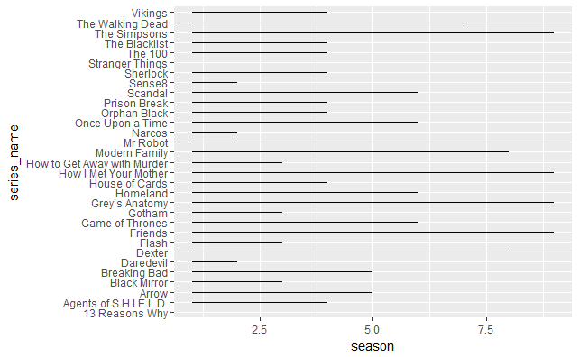

```r
ggplot(data=series,
       aes(y=series_name, x=season)) +
       geom_line()
```

Algumas séries com personagens principais masculinos

```r
masculino=series %>% filter(series_name %in% c("Mr Robot", "Breaking Bad","Vikings",                                           "Gotham"))
```

Agora, algumas séries com personagens principais femininos

```r
feminino=series %>% filter(series_name %in% c("13 Reasons Why", "Orphan Black", "How to Get Away with Murder", "Grey/'s Anatomy"))
```

Olhando rapidamente para as medias 10 das séries masculinas

```r
mean(masculino$r10)
```

```
[1] 0.4157412
```

Olhando rapidamente para as médias 10 das séries femininas

```r
mean(feminino$r10)
```

```
[1] 0.3827658
```

Mas como média é bastante influenciada por valores extremos, vamos observar um boxplot dos dados.

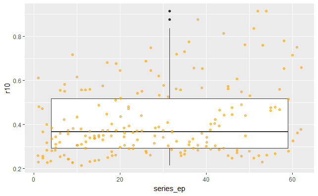

```r
ggplot(masculino, aes(x = series_ep, y = r10 )) +
  geom_boxplot() +
  geom_jitter(color = "orange", width = .1, height = 0, alpha = .6)
```

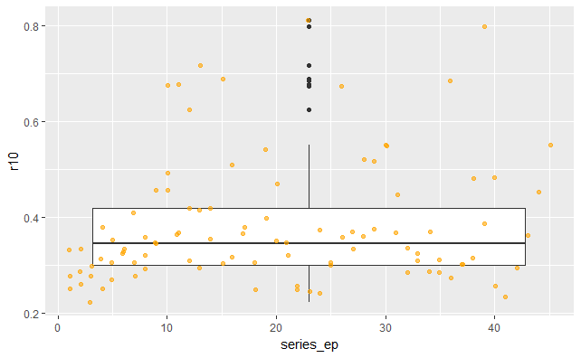

```r
ggplot(feminino, aes(x = series_ep, y = r10 )) +
  geom_boxplot() +
  geom_jitter(color = "orange", width = .1, height = 0, alpha = .6)
```

Curiosamente, ambos possuem metade das observações de r10 concentrados abaixo de 0.4. Nenhuma novidade, já que isso quer dizer apenas que é dificil fazer um episodio nota 10.

Já pelo outro lado, ambos possuem a segunda metade muito dispersa. Aparentemente não há relação entre a proporção de nota 10 e se o personagem é masculino ou feminino para os dados que eu selecionei.

5-Se eu criasse uma temporada de 10 episodios com o episodio mais bem avaliado de cada indice entre todas as series e temporadas, quais series estariam presentes nessa temporada dos sonhos? Exemplo: um conjunto de episodios composto pelo primeiro episodio mais bem avaliado seguido do segundo episodio mais bem avaliado … e assim por diante. Pelo menos breaking bad,game of thrones